# Report

## Introduction

The purpose of this project is to investigate music trends using the Spotify Charts website. We wanted to explore the top Spotify artists and genres over a specific period of time. This report outlines our process, from scraping the data from the website, cleaning the data, creating functions to analyze the data, to an interactive Shiny app. In addition, we used the Spotify API to help generate the genre for the top tracks as that is not included in the charts.

## Initial Exploration

The first thing we must do is bring the data into R. We do so by scraping the table from the Spotify Charts website. The url used in this section of the report opens the Top 200 Songs globally for the week of April 8th - April 15th 2022.

Initially, our data only shows the title of the track and the number of streams. We need to find a way to add the artists to this data.

```
## # A tibble: 6 × 3
##   Number Track                                                         Streams
##    <int> <chr>                                                         <chr>
## 1      1 "As It Was\n                                                … 67,265,7…
## 2      2 "First Class\n                                              … 50,438,2…
## 3      3 "Heat Waves\n                                               … 29,307,7…
## 4      4 "STAY (with Justin Bieber)\n                                … 23,354,8…
## 5      5 "Enemy (with JID) - from the series Arcane League of Legends… 21,330,2…
## 6      6 "Envolver\n                                                 … 20,197,0…
```

To add an artist column, we can use Selector Gadget to find the specific node id for artists. We extract the artists from the site as a column and append it to our data.

```
## # A tibble: 6 × 4
##   Number Track                                             Streams   Artist
##    <int> <chr>                                             <chr>     <chr>
## 1      1 "As It Was\n                                    … 67,265,7… Harry Styl…
## 2      2 "First Class\n                                  … 50,438,2… Jack Harlow
## 3      3 "Heat Waves\n                                   … 29,307,7… Glass Anim…
## 4      4 "STAY (with Justin Bieber)\n                    … 23,354,8… The Kid LA…
## 5      5 "Enemy (with JID) - from the series Arcane Leagu… 21,330,2… Imagine Dr…
## 6      6 "Envolver\n                                     … 20,197,0… Anitta
```

The next step is to clean the data. We still have a new line and the artist name in the track title, and streams are recorded as characters, not integers. Once we remedy this, we have our final data.

```
## # A tibble: 6 × 4
##   Number Track                                             Streams Artist
##    <int> <chr>                                               <int> <chr>
## 1      1 As It Was                                          6.73e7 Harry Styles
## 2      2 First Class                                        5.04e7 Jack Harlow
## 3      3 Heat Waves                                         2.93e7 Glass Animals
## 4      4 STAY (with Justin Bieber)                          2.34e7 The Kid LAROI
## 5      5 Enemy (with JID) - from the series Arcane League…  2.13e7 Imagine Drag…
## 6      6 Envolver                                           2.02e7 Anitta
```

Now we can create some basic visualizations. The first thing we wanted to see was the top tracks for the week.

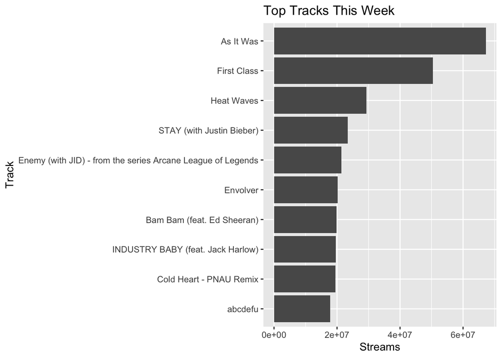

We see that As It Was by Harry Styles is extremely popular this week!

Next we can explore the number of hits artists have had chart this week.

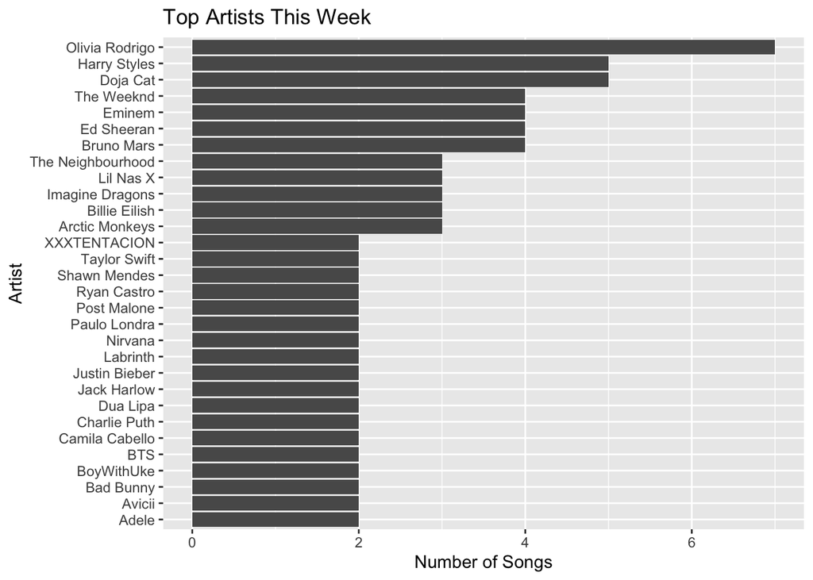

Olivia Rodrigo was extremely popular, with 7 songs on the Top 200 this week.

## Using Spotify API to add Genre

As seen, the charts are limited to Songs, their Artists and the number of Streams. So, here we add “genre” for each song by accessing the Spotify API.

### Before we proceed, let’s explain HOW the Spotify API works.

The Spotify API has various Endpoints like “Get Artist”, “Get Album”, “Search Item” etc. which return the resources we need, when received a “GET” request from the User.

This GET request requires Authorization in the form of Access tokens, which in turn can be generated by a specific set of Client ID and Secret provided to Spotify Users after registration.

However, these tokens have a lifespan of 60 minutes so we need to regenerate them before using them.

This is how a RESPONSE from one such Endpoint (Get Artist) looks like:

```
## [[1]]
## [1] "chill r&b"
##
## [[2]]
## [1] "pop"
```

### Adding Genre

Spotify doesn’t store a “genre” of a song explicitly so we can search the song from the API, get the relevant Album the song is a part of, and then extract the genre. This approach is tedious and faces other issues like not having an album allotted to the songs at all.

Instead, we search for Genres the Artist of the song is related to. Accessing the Genre from “Get Artist” endpoint would require a Spotify ID defined Artist ID for each Artist on that platform, with no feasible way of accessing them, besides performing a hard search on Google, opening the respective Artist’s Spotify Page and then extracting the last few characters from the URL!

So, we use the “Search Item” endpoint, where it is possible to search for Artists by their names (as provided in the chart!) and get the Genres there itself. This, however, assumes that no Artist Name is repeated.

To sum it up, from the Scraped Data, we will pass the Artists’ Names to the Search Item endpoint of Spotify API and retrieve the Genre for the best matched Artist!

An instance, after adding genres and splitting/unnest-ing the same (since genres are stored as lists) looks as follows:

```
## # A tibble: 6 × 4
##   Number Track       Artist        Genres
##    <int> <chr>       <chr>         <chr>
## 1      1 As It Was   Harry Styles  pop
## 2      2 First Class Jack Harlow   deep underground hip hop
## 3      2 First Class Jack Harlow   kentucky hip hop
## 4      2 First Class Jack Harlow   rap
## 5      3 Heat Waves  Glass Animals gauze pop
## 6      3 Heat Waves  Glass Animals indietronica
```

## Expanding our Scraping

The Top Charts displayed can be modified for two parameters: Region and Time (Daily and Weekly).

The typical URL looks as follows:

“https://spotifycharts.com/regional/global/daily/latest”

As seen above, the “global” part in URL determines region, and can be substituted for various other regions like USA, UK or many others. Similarly, the “daily” part can be altered with “weekly”, fetching results for the latest week.

But that isn’t all there is to the time frame! Charts from older days and weeks can be fetched as well:

“https://spotifycharts.com/regional/global/weekly/2022-04-22--2022-04-29”

Above is one such example wherein an older week’s chart was retrieved using the URL above.

Now that we know that we can acquire older data by modifying the URL, we will do so and generate Monthly Data (assuming 4 previous weeks constitute a month) and Yearly data (assuming 48 weeks form a year).

Following is how the generated dates range for weekly URL look like:

```
## [1] "2022-04-29--2022-05-06" "2022-04-22--2022-04-29" "2022-04-15--2022-04-22"
## [4] "2022-04-08--2022-04-15"
```

These can then, along with the Regions, be appended to the URL and be used to retrieve Scraped Data for various combinations.

## Shiny Application

Using the previously defined functions up until now, we will integrate them all in a Shiny Application which dynamically displays two plots : Top Genres and Top Artists for a specific Region and Time Frame.

Disclaimer: Generating Plots takes some time since scraping, and running several API requests (the same number as artists present in the chart) happens in real time which can cause some delay. This is done in order to fetch real data and make this application dynamic in nature! So, it is requested that you do not spam the “Generate Plots” button, and patiently wait.

Shiny applications not supported in static R Markdown documents

### Note: Be sure to close the shiny tab WHILE running chunk wise. Otherwise the RStudio gets stuck “Listening on http://127.0.0.1:7302”. Other way to escape the same is by hitting the escape key in the console tab

## Finding Top Artists and Genres Trends in the Past Year

Here, we plot the Top 10 Artists for the previous year, and see how many streams they had per month for that year.

Note: This Plot doesn’t show the Top 10 Artists in 2021, rather it calculates trends back in the Past Year, starting our count from today or current week itself. Hence, Month 12 denotes the latest 4 weeks (assumed to be Month) and not December, per se.

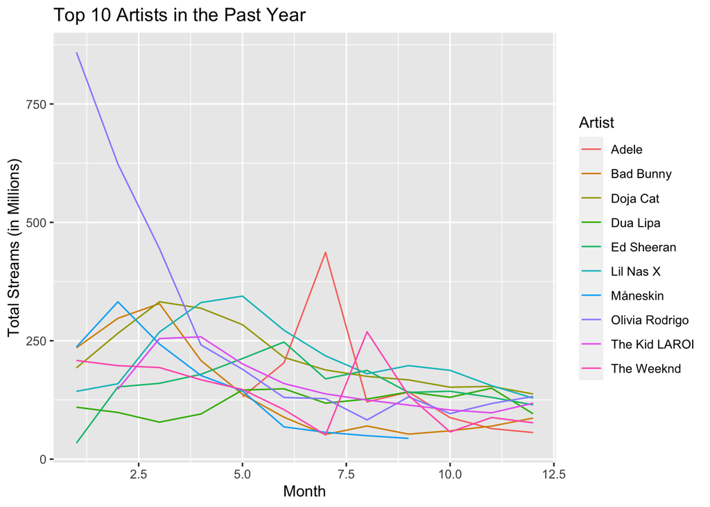

As seen, Olivia Rodrigo had a peak which dates back to last year’s May.

The investigation of that month looks as follows:

```
## # A tibble: 61 × 2
##    Artist             n
##    <chr>          <int>
##  1 Olivia Rodrigo    37
##  2 The Weeknd        12
##  3 Måneskin          11
##  4 Bad Bunny          9
##  5 Jhay Cortez        9
##  6 BTS                8
##  7 Doja Cat           8
##  8 Rauw Alejandro     8
##  9 Maria Becerra      7
## 10 J Balvin           6
## # … with 51 more rows
```

In the tibble, the sum corresponds to the number of appearances Olivia Rodrigo had in top 50 each week of that month!

Meaning, she had a very successful month!

### Plotting the same for Genres in the Past Year

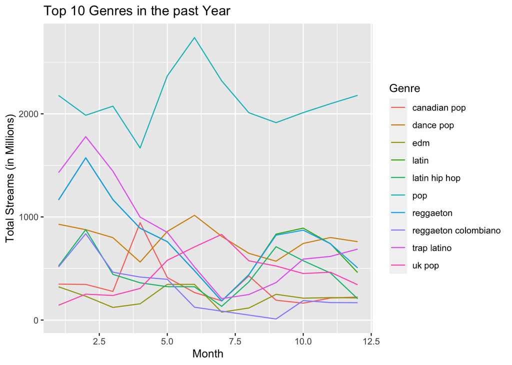

Many of the genres in the Top 10 are Latin based, which indicates that Spotify has an active community of Latin Listeners! But as usual, Pop genre beats the rest by a huge margin!